# hastyDE versus limmaDE

A focused simulation study for SpaceMosaic

## Question

**Does limma’s empirical-Bayes variance moderation improve the stability of gene-level inference relative to the current matrix-based OLS method, while leaving estimated effects and model residuals unchanged?**

`hastyDE()` is computationally efficient, but estimates each gene’s residual variance independently. This can be unstable in small spatial patches. `limmaDE()` fits the same linear models and then uses `limma::eBayes()` to share variance information across genes. The comparison therefore isolates the effect of variance moderation without changing the underlying regression.

## Why simulation is the appropriate tool

Real data do not reveal which genes truly have an effect. Simulation gives us known ground truth, allowing us to evaluate both null calibration and detection power. The same simulated matrices and design are passed to both methods, so any difference in standard errors or p-values can be attributed to empirical Bayes moderation.

We examine two scenarios:

1. **Gaussian expression**, which directly matches the linear-model assumptions.
2. **Count-derived Pearson residuals**, which resembles the intended SpaceMosaic preprocessing. This is not a voom analysis: both methods receive the same residual matrix.

## Simulation design

We simulate one small patch containing 16 cells and 1,000 genes. The first 100 genes have a non-zero exposure effect; the other 900 are null. Gene-specific variances are heterogeneous so that variance moderation has something meaningful to estimate.

```r
set.seed(18)

n_cells <- 16L
n_genes <- 1000L
n_de <- 100L
gene_names <- paste0("gene_", seq_len(n_genes))
is_de <- seq_len(n_genes) <= n_de
exposure <- as.numeric(scale(stats::rnorm(n_cells)))
df <- data.frame(exposure = exposure)

sigma <- exp(stats::rnorm(n_genes, mean = 0, sd = 0.7))
beta <- numeric(n_genes)
beta[is_de] <- 0.5 * sigma[is_de]
baseline <- stats::rnorm(n_genes, mean = 5, sd = 1)

y_gaussian <- outer(rep(1, n_cells), baseline) +
  outer(exposure, beta) +
  matrix(stats::rnorm(n_cells * n_genes), nrow = n_cells) *
  rep(sigma, each = n_cells)
colnames(y_gaussian) <- gene_names
rownames(y_gaussian) <- paste0("cell_", seq_len(n_cells))

library_size <- round(exp(stats::rnorm(n_cells, log(1000), 0.35)))
abundance <- exp(stats::rnorm(n_genes, log(0.02), 0.8))
count_beta <- numeric(n_genes)
count_beta[is_de] <- 0.12
mu <- outer(library_size, abundance) * exp(outer(exposure, count_beta))
y_counts <- matrix(
  stats::rnbinom(n_cells * n_genes, mu = as.vector(mu), size = 10),
  nrow = n_cells,
  dimnames = list(rownames(y_gaussian), gene_names)
)
y_pearson <- pearsonResiduals(y_counts, tot = library_size)
```

## Model comparison

For both scenarios, `limmaDE()` uses `trend = FALSE`: Pearson residuals are already designed to remove the count mean-variance relationship, and the Gaussian simulation has no imposed mean-variance trend. Robust empirical Bayes estimation protects the hyperparameter estimates from unusually variable genes.

```r
fit_pair <- function(y) {
  list(
    hasty = hastyDE(y, df, return_residuals = TRUE),
    limma = limmaDE(
      y, df,
      return_residuals = TRUE,
      trend = FALSE,
      robust = TRUE
    )
  )
}

gaussian_fit <- fit_pair(y_gaussian)
pearson_fit <- fit_pair(y_pearson)
```

The maximum absolute discrepancies confirm that both approaches fit the same coefficients and residuals:

| Quantity | Maximum absolute difference |
| --- | --- |
| Gaussian effects | 0 |
| Gaussian residuals | 0 |
| Pearson effects | 0 |
| Pearson residuals | 0 |

## Results

| Scenario | Method | False-positive rate | Power | Median SE |
| --- | --- | --- | --- | --- |
| Gaussian expression | hasty | 0.059 | 0.46 | 0.244 |
| Gaussian expression | limma | 0.054 | 0.42 | 0.239 |
| Pearson residuals | hasty | 0.033 | 0.10 | 0.429 |
| Pearson residuals | limma | 0.040 | 0.14 | 0.427 |

The false-positive rate is the fraction of null genes with (p < 0.05). Power is the corresponding fraction among truly non-null genes. These values describe one realization and should not be interpreted as stable performance estimates.

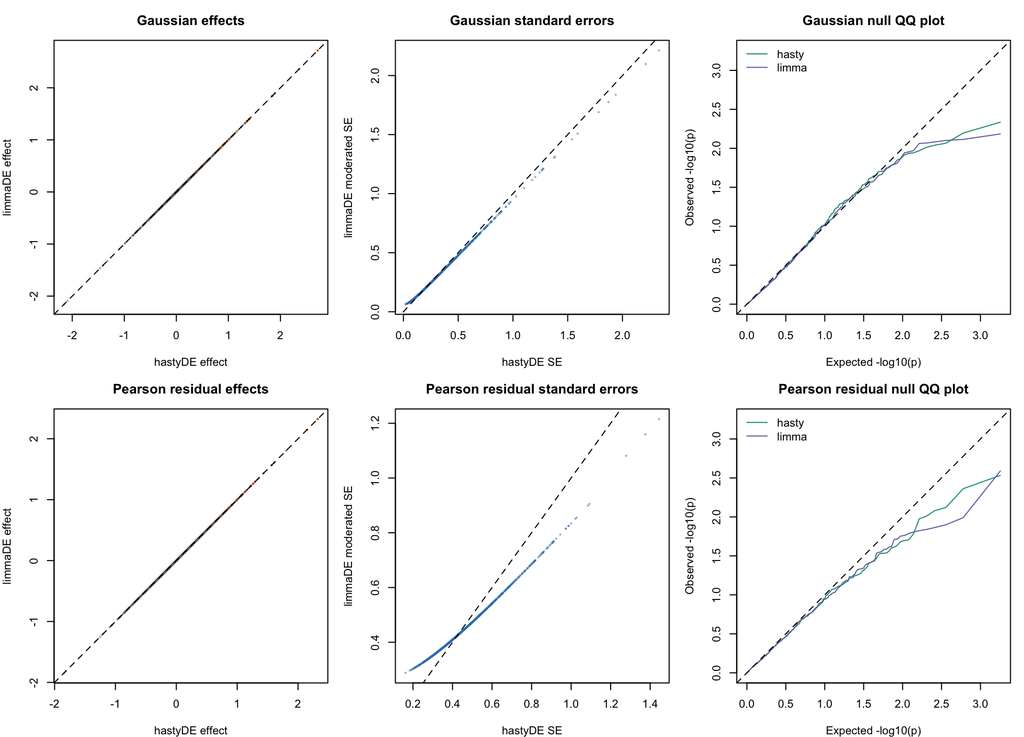

### How to interpret the panels

- **Effects:** points on the identity line confirm that empirical Bayes does not alter coefficients. Orange points are truly non-null genes; grey points are null genes.
- **Standard errors:** points above the identity line indicate that limma increased an unusually small SE; points below indicate shrinkage of an unusually large SE. This stabilization is the intended effect of moderation.
- **Null QQ plots:** the diagonal represents uniformly distributed null p-values. Curves above it suggest too many small p-values; curves below it indicate conservative inference.

## Small real-data example

### Question

**Across small data-driven spatial patches, how much does limma moderation change uncertainty and gene prioritization relative to hastyDE?**

Unlike the simulation, real data provide no ground truth. This section therefore does not ask which method is more accurate. It asks whether empirical-Bayes moderation has a material practical effect when the model, cells, genes and response transformation are held fixed.

We use the mouse-colon spatial transcriptomics dataset distributed with SpaceMosaic. The analysis mirrors the immune-surveillance scenario in the main vignette: patches are constructed among epithelial cells to retain local variation in the number of immune cells in each cell’s 100-nearest-neighbour environment. Differential expression is then fitted separately within every eligible patch.

### Patch construction and gene filtering

We first calculate immune density and a cellular-neighbourhood embedding on the complete tissue. We then use `getPatches()` on all epithelial cells, using spatial coordinates, immune density and neighbourhood context to create 100 candidate patches. Patch construction is completed before gene expression is tested and uses no gene-level DE statistics, so it is independent of the comparison between hastyDE and limmaDE.

Genes are filtered once across **all epithelial cells**, retaining genes detected in at least 5% of them. This preserves a common gene universe selected without using the predictor associations or their p-values. Library totals are calculated from the original unfiltered count matrix, as required for Pearson residuals.

```r
required_real_packages <- c("FNN", "ggplot2", "HDF5Array", "SpatialExperiment")
missing_real_packages <- required_real_packages[
  !vapply(required_real_packages, requireNamespace, logical(1), quietly = TRUE)
]
if (length(missing_real_packages) > 0L) {
  stop("Missing packages: ", paste(missing_real_packages, collapse = ", "))
}
suppressPackageStartupMessages(library(ggplot2))

spe <- HDF5Array::loadHDF5SummarizedExperiment(
  file.path("inst", "extdata", "mouse_colon")
)
counts <- SummarizedExperiment::assay(spe, "counts")
xy <- SpatialExperiment::spatialCoords(spe)
cell_type <- spe$tier1
is_epithelial <- cell_type == "Epithelial"
is_immune <- cell_type == "Immune"
Z <- embedCellNeighborhoods(
  mat = SingleCellExperiment::reducedDim(spe, "PCA"),
  xy = xy,
  ks = c(5, 50)
)

nn_all <- FNN::get.knn(as.matrix(xy), k = 100)$nn.index
immune_density <- rowSums(
  matrix(is_immune[nn_all], nrow = nrow(xy))
)

epithelial_index <- which(is_epithelial)
epithelial_xy <- xy[epithelial_index, , drop = FALSE]
detection_rate <- Matrix::rowMeans(counts[, is_epithelial, drop = FALSE] > 0)
keep_gene <- detection_rate >= 0.05

rownames(epithelial_xy) <- spe$cell_id[epithelial_index]
set.seed(123)
patch_fit <- getPatches(
  xy = epithelial_xy,
  X = immune_density[is_epithelial],
  npatches = 100,
  Z = Z[is_epithelial, , drop = FALSE],
  n_iters = 10,
  log_iters = TRUE,
  verbose = FALSE
)

patch_diagnostics <- getPatchDiagnostics(
  xy = epithelial_xy,
  patches = patch_fit,
  X = immune_density[is_epithelial]
)

eligible_patch <- patch_diagnostics$patch_diagnostics[
  patch_diagnostics$patch_diagnostics$n_cells >= 30 &
    is.finite(patch_diagnostics$patch_diagnostics$x_sd) &
    patch_diagnostics$patch_diagnostics$x_sd > 0, "patch"
]

selected_epithelial <- !is.na(patch_fit$patch) & patch_fit$patch %in% eligible_patch
selected_index <- epithelial_index[selected_epithelial]
selected <- seq_len(ncol(counts)) %in% selected_index

selected_totals <- Matrix::colSums(counts[, selected, drop = FALSE])
real_y <- t(counts[keep_gene, selected, drop = FALSE])
real_df <- data.frame(immune_density = immune_density[selected])
real_patch <- patch_fit$patch[selected_epithelial]

poly_df <- getPatchPolys(
  xy = epithelial_xy[selected_epithelial, , drop = FALSE],
  patch = real_patch,
  patch_data = patch_diagnostics$patch_diagnostics[
    patch_diagnostics$patch_diagnostics$patch %in% eligible_patch,]
)
```

Of 100 requested patches, 98 pass the eligibility rule, containing 10470 epithelial cells in total. Eligible patch sizes range from 49 to 177 cells; 324 genes pass global filtering. Immune-neighbour counts range from 0 to 29.

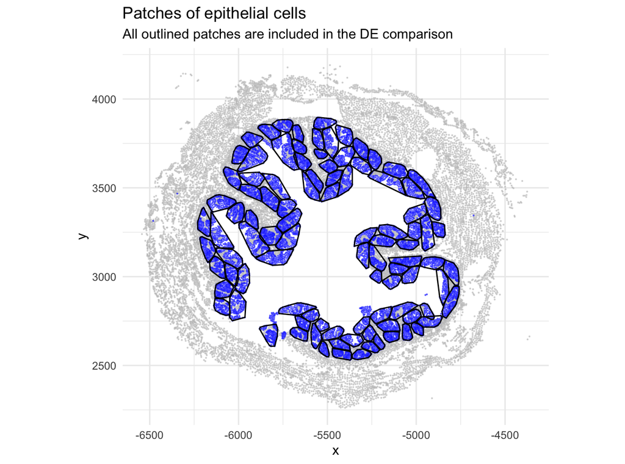

### Same data and model, different variance inference

Both calls below compute the same patch-specific Pearson residuals. The only difference is whether residual variances are estimated independently by OLS or moderated across genes by limma.

```r
hasty_timing <- system.time(real_hasty <- patchDE(
  y = real_y,
  df = real_df,
  patch = real_patch,
  method = "hasty",
  pearson = TRUE,
  tot = selected_totals,
  return_residuals = TRUE,
  verbose = FALSE
))
limma_timing <- system.time(real_limma <- patchDE(
  y = real_y,
  df = real_df,
  patch = real_patch,
  method = "limma",
  pearson = TRUE,
  tot = selected_totals,
  return_residuals = TRUE,
  verbose = FALSE
))

hasty_result <- real_hasty$de$immune_density
limma_result <- real_limma$de$immune_density
real_effect_difference <- max(
  abs(hasty_result$ests - limma_result$ests), na.rm = TRUE
)
real_residual_difference <- max(
  abs(real_hasty$residuals - real_limma$residuals), na.rm = TRUE
)
```

As expected for the same linear model, the maximum absolute effect difference is 4.55e-15 and the maximum residual difference is 1.42e-14.

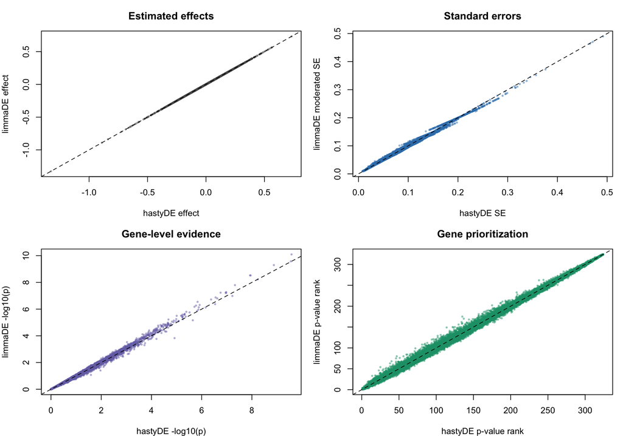

The effects remain fixed, whereas movement away from the identity line in the other panels quantifies the practical impact of moderation. In particular, ranking changes occur because limma stabilizes gene-wise uncertainty, not because it changes the estimated association.

### Impact on nominal significance calls

Patch-level p-values are not adjusted for testing many genes across many patches. Consequently, the threshold (p < 0.05) is used here only as a descriptive reference point. These are **nominal calls**, not reportable DE discoveries; multiplicity should be addressed at the final meta-analysis stage.

| Classification | Gene-patch pairs | Percent |
| --- | --- | --- |
| Significant with both methods | 3035 | 9.63 |
| hastyDE only | 118 | 0.37 |
| limmaDE only | 144 | 0.46 |
| Not significant with either method | 28220 | 89.54 |

The following table focuses on the top 10 discordant pairs: cases where the selected DE backend changes whether the nominal threshold is crossed. Pairs are ordered by their strongest p-value, so the table emphasizes changes closest to the evidence-bearing end of the results rather than the largest arbitrary rank movements.

| Gene | Patch | Effect | hasty SE | limma SE | hasty p | limma p | Nominal call |
| --- | --- | --- | --- | --- | --- | --- | --- |
| Lif | 2 | 0.0619 | 0.0273 | 0.0357 | 0.0256 | 0.0849 | hastyDE only |
| Nlrp3 | 86 | 0.0653 | 0.0292 | 0.0331 | 0.0274 | 0.0509 | hastyDE only |
| C1qtnf12 | 97 | 0.0798 | 0.0366 | 0.0417 | 0.0333 | 0.0591 | hastyDE only |
| Gfra3 | 78 | -0.0990 | 0.0456 | 0.0530 | 0.0337 | 0.0649 | hastyDE only |
| Phgdh | 9 | 0.0199 | 0.0093 | 0.0101 | 0.0352 | 0.0504 | hastyDE only |
| Jag1 | 60 | -0.0485 | 0.0228 | 0.0259 | 0.0360 | 0.0636 | hastyDE only |
| Dll4 | 77 | -0.1664 | 0.0845 | 0.0787 | 0.0529 | 0.0369 | limmaDE only |
| Bmi1 | 2 | 0.0748 | 0.0353 | 0.0402 | 0.0370 | 0.0652 | hastyDE only |
| Cxcl14 | 17 | 0.0687 | 0.0325 | 0.0388 | 0.0378 | 0.0788 | hastyDE only |
| Mmp28 | 64 | 0.1148 | 0.0547 | 0.0595 | 0.0380 | 0.0555 | hastyDE only |

Discordance arises only from variance moderation: the estimated effect is the same, but the moderated standard error changes the corresponding test statistic and p-value.

### Runtime

| Method | Elapsed seconds |
| --- | --- |
| hasty | 7.941 |
| limma | 8.553 |

These timings describe one execution across the eligible patches on the current machine. They show practical overhead but are not a full benchmark.

## Conclusion and limitations

This toy study confirms the intended mechanism: `limmaDE()` preserves the estimated effects and residuals while moderating uncertainty across genes. In this realization, both methods show broadly similar null calibration, while the changes in standard errors are clearly visible. The real-data example then shows how those changes propagate to p-values and within-patch gene prioritization across data-driven spatial patches, without implying that either ranking is ground truth.

The study is deliberately small and explanatory. It does **not** establish that one method is generally superior. A decision about the default SpaceMosaic backend should rely on repeated simulations spanning patch size, sparsity, effect size, variance heterogeneity and residual spatial autocorrelation.